# BioMassters: Estimating biomass in Finnish forests

Measuring the power of forests as carbon sinks provides incentive to consider the environmental value of forests and contribute to the global goal of halting deforestation.

BioMassters

meet the team:

Sofia Matias - CEO / Data Engineer

Emile van Cauwenberghe - Machine Learning Engineer

Pedro Lopes - Machine Learning Engineer

Luis Sarmento - ML Ops / Data Scientist

## The problem at a glance

Goal: To estimate the yearly biomass of different sections of Finland's forests.

Idea: Remote sensing methods, such as satellite imagery, offer a much faster, less intrusive, cheaper and more wide spread biomass estimate.

Challenge: Both satellites use a total of 15 different sensors to create a gridded section image of the forest.

Using Deep Learning models, we aim at predicting the total biomass

The challenge-winning biomass algorithm will be adjusted and scaled globally using ground truth measurements from forests around the world.

The algorithm could be extended to many different types of forest biomass, from boreal to temperate, and from tropical to arid.

001b0634_S2_00.tif is an image from Satellite2 that is part of the training dataset. Its name indicates it is for chip 001b0634 and collected by Satellite2 during September.

- Presentation of the dataset (main considerations only - rows, cols, key features, target if any)
- High level overview of the data preprocessing (highlight just the key actions, not all)
- Comparison of the different models (and metrics that made you chose the final one)
- Brief explanation of the final model and tuning (understandable for regular humans)
- Move to the Streamlit demo (feel free to get very creative!)
- Key learnings/impacts and next steps (to improve the project)
- Keep the design clean and cohesive
- When using text, keep a consistent and large font size
- Whenever you can, favor (good) visualisation over text
- Try to avoid excessive technical jargon as much as you can

```python
complete_months = ["April", "May", "June", "July", "August"]
```

```python
months_24 = months[months["month"]==24]
```

```python
months_24
```

| chip_id | filename | satellite | split | month | size | cksum | s3path_us | s3path_eu | s3path_as | corresponding_agbm | file_downloaded | file_in_GCS |
| --- | --- | --- | --- | --- | --- | --- | --- | --- | --- | --- | --- | --- |
| 0060c0a5 | 24 | 24 | 24 | 24 | 24 | 24 | 24 | 24 | 24 | 24 | 24 | 24 |
| 00e6b793 | 24 | 24 | 24 | 24 | 24 | 24 | 24 | 24 | 24 | 24 | 24 | 24 |
| 00fd0698 | 24 | 24 | 24 | 24 | 24 | 24 | 24 | 24 | 24 | 24 | 24 | 24 |
| 010966cb | 24 | 24 | 24 | 24 | 24 | 24 | 24 | 24 | 24 | 24 | 24 | 24 |
| 017f206b | 24 | 24 | 24 | 24 | 24 | 24 | 24 | 24 | 24 | 24 | 24 | 24 |
| ... | ... | ... | ... | ... | ... | ... | ... | ... | ... | ... | ... | ... |
| ff7589c0 | 24 | 24 | 24 | 24 | 24 | 24 | 24 | 24 | 24 | 24 | 24 | 24 |
| ff9b942d | 24 | 24 | 24 | 24 | 24 | 24 | 24 | 24 | 24 | 24 | 24 | 24 |
| ffa9b9f1 | 24 | 24 | 24 | 24 | 24 | 24 | 24 | 24 | 24 | 24 | 24 | 24 |
| ffb7d809 | 24 | 24 | 24 | 24 | 24 | 24 | 24 | 24 | 24 | 24 | 24 | 24 |
| ffde1ed8 | 24 | 24 | 24 | 24 | 24 | 24 | 24 | 24 | 24 | 24 | 24 | 24 |

1790 rows × 12 columns

```python
1790*0.156168
```

```
279.54072
```

```python
len(months_24)/len(months)
```

```
0.1561682079916245
```

```python
months_up_to = months[months["month"]<=17]
```

```python
len(months_up_to)/len(months)
```

```
0.04519281102774385
```

```python
train_agbm.head(5)
```

|  | filename | chip_id | size | cksum | s3path_us | s3path_eu | s3path_as |
| --- | --- | --- | --- | --- | --- | --- | --- |
| 0 | 0003d2eb_agbm.tif | 0003d2eb | 262482 | 2036246549 | s3://drivendata-competition-biomassters-public-us/train_agbm/0003d2eb_agbm.tif | s3://drivendata-competition-biomassters-public-eu/train_agbm/0003d2eb_agbm.tif | s3://drivendata-competition-biomassters-public-as/train_agbm/0003d2eb_agbm.tif |
| 1 | 000aa810_agbm.tif | 000aa810 | 262482 | 2858468457 | s3://drivendata-competition-biomassters-public-us/train_agbm/000aa810_agbm.tif | s3://drivendata-competition-biomassters-public-eu/train_agbm/000aa810_agbm.tif | s3://drivendata-competition-biomassters-public-as/train_agbm/000aa810_agbm.tif |
| 2 | 000d7e33_agbm.tif | 000d7e33 | 262482 | 277850822 | s3://drivendata-competition-biomassters-public-us/train_agbm/000d7e33_agbm.tif | s3://drivendata-competition-biomassters-public-eu/train_agbm/000d7e33_agbm.tif | s3://drivendata-competition-biomassters-public-as/train_agbm/000d7e33_agbm.tif |
| 3 | 00184691_agbm.tif | 00184691 | 262482 | 3502312579 | s3://drivendata-competition-biomassters-public-us/train_agbm/00184691_agbm.tif | s3://drivendata-competition-biomassters-public-eu/train_agbm/00184691_agbm.tif | s3://drivendata-competition-biomassters-public-as/train_agbm/00184691_agbm.tif |
| 4 | 001b0634_agbm.tif | 001b0634 | 262482 | 2397957274 | s3://drivendata-competition-biomassters-public-us/train_agbm/001b0634_agbm.tif | s3://drivendata-competition-biomassters-public-eu/train_agbm/001b0634_agbm.tif | s3://drivendata-competition-biomassters-public-as/train_agbm/001b0634_agbm.tif |

```python
# Read tif file and get a numpy array
def image_to_np(path, filename):
  file = os.path.abspath(f'{path}{filename}')
  return tifffile.imread(file)
```

```python
XS1 = image_to_np('../data/train data/' , '0060c0a5_S1_00.tif')
XS2 = image_to_np('../data/train data/' , '0060c0a5_S2_06.tif')

y = image_to_np('../data/ground truth/' , '0060c0a5_agbm.tif')
```

```python
y
```

```
array([[166.4 , 170.57, 114.  , ...,   0.  ,   0.  ,   0.  ],
       [128.86, 115.34, 212.28, ...,   0.  ,   0.  ,   0.  ],
       [128.86, 115.34, 212.28, ...,   0.  ,   0.  ,   0.  ],
       ...,
       [167.07, 144.26, 203.56, ..., 273.55, 329.19, 280.63],
       [219.11, 221.05, 211.61, ..., 328.53, 348.27, 248.67],
       [219.11, 221.05, 211.61, ..., 328.53, 348.27, 248.67]],
      dtype=float32)
```

```python
data = image_to_np('../data/train data/' , '0060c0a5_S1_00.tif')
```

[output not shown]

### 1.1.1) Compress Data (?)

Do we need to do this - change dtypes?

## 1.2) Clean Data

Do we need to do this? How do we deal with the months data?

## 1.3) Visualize Data

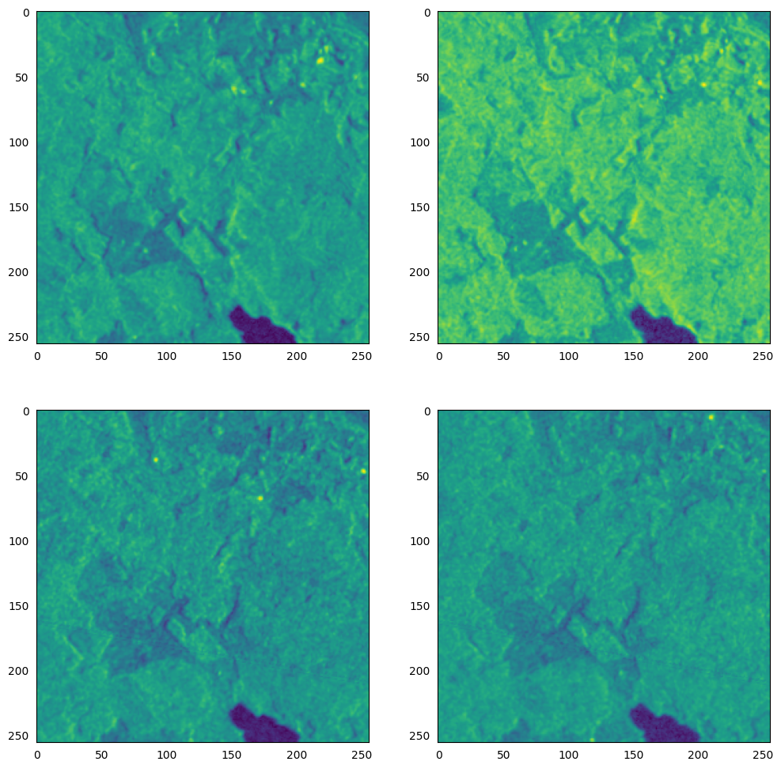

```python
# Function to visualize S1 bands
def S1_view (img):
    _, ax = plt.subplots(2,2, figsize=(12,12))
    ax[0,0].imshow(img[:,:,0]);
    ax[0,0].tick_params(bottom=False, left=False)
    ax[0,1].imshow(img[:,:,1]);
    ax[0,1].tick_params(bottom=False, left=False)
    ax[1,0].imshow(img[:,:,2]);
    ax[1,0].tick_params(bottom=False, left=False)
    ax[1,1].imshow(img[:,:,3]);
    ax[1,1].tick_params(bottom=False, left=False)
    img.shape

S1_view(XS1)
```

[output not shown]

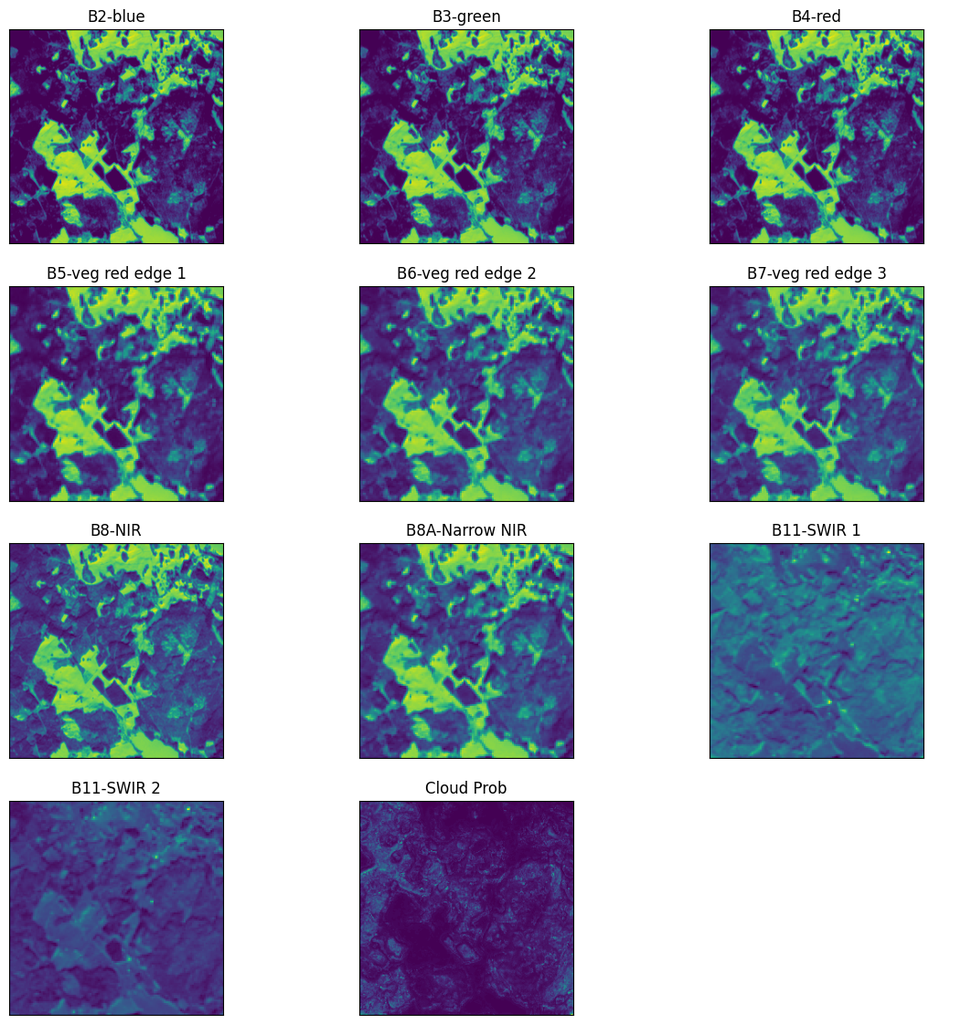

```python
# Function to visualize the 11 bands from S2 images
def S2_image(img):
    axes = [[0,0], [0,1], [0,2], [1,0], [1,1], [1,2], [2,0], [2,1], [2,2],
            [3,0], [3,1]]
    images = list(range(11))
    titles = ['B2-blue','B3-green','B4-red', 'B5-veg red edge 1',
              'B6-veg red edge 2', 'B7-veg red edge 3', 'B8-NIR',
              'B8A-Narrow NIR', 'B11-SWIR 1', 'B11-SWIR 2', 'Cloud Prob']

    fig, ax = plt.subplots(4,3, figsize=(14,14))

    for ij, img_num, title in zip(axes, images, titles):
            ax[ij[0],ij[1]].imshow(img [:, :, img_num]);
            ax[ij[0],ij[1]].set_title(title)
            ax[ij[0],ij[1]].tick_params(bottom=False, left=False, labelbottom=False, labelleft=False)

    plt.axis('off')
    ax[3,2].tick_params(bottom=False, left=False, labelbottom=False, labelleft=False)

S2_image(XS2)
XS2
```

```python
XS1[0].shape
```

```
(256, 4)
```

```
([], [])
```

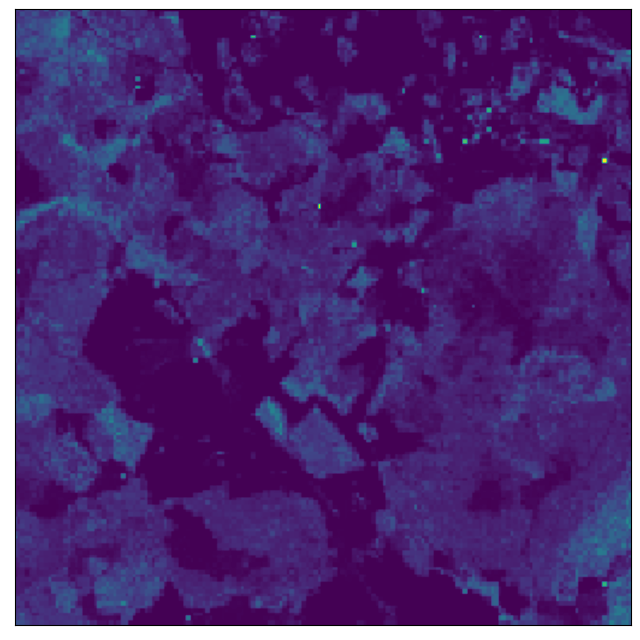

```python
# Visualizing LiDAR image
plt.figure(figsize = (8,8))
plt.imshow(y)
plt.xticks([])
plt.yticks([])
```

# 3) Model

```python
def define_model_supersimple_convnet():
    model = tf.keras.Sequential(
        [
            tf.keras.layers.Conv2D(
                15,
                1,
                padding="same",
                activation="relu",
                input_shape=(256, 256),
            ),
            tf.keras.layers.MaxPooling2D(),
            tf.keras.layers.Conv2D(32, 3, padding="same", activation="relu"),
            tf.keras.layers.MaxPooling2D(),
            tf.keras.layers.Conv2D(64, 3, padding="same", activation="relu"),
            tf.keras.layers.MaxPooling2D(),
            tf.keras.layers.Dropout(0.2),
            tf.keras.layers.Flatten(),
            tf.keras.layers.Dense(128, activation="relu"),
            tf.keras.layers.Dense(2, activation="softmax")
        ]
    )

    model.compile(
        optimizer=tf.keras.optimizers.Adam(
            learning_rate=3e-4
        ),  # this LR is overriden by base cycle LR if CyclicLR callback used
        loss="sparse_categorical_crossentropy",
        metrics=["accuracy"],
    )

    print(model.summary())

    return model
```

```python
# update: fit_generator will be deprecated: use fit instead -> apparently works faster with Tensorflow 2.0

model = define_model_supersimple_convnet()
history = model.fit(test[0],
  steps_per_epoch=1000,
  epochs=35,
 )
```

[output not shown]

[output cut: 54 more lines]

```python
test[3].shape
```

```
(256, 256)
```

```python
test = XS1.T
```

```python
XS1[0].shape
```

```
(256, 4)
```

```python
model.predict(XS1, XS2)
```

[output not shown]

```python
# A pixel value of -9999 indicates missing data
```

```python
def create_model(data,  eurosat_url='../Weights of pretrained model/Model-multispectral-0.99'):
    print('Importing custom xresnet50 pretrained on eurosat')

    model = xresnet50(c_in=13, c_out=10)
    st = torch.load(eurosat_url)
    model.load_state_dict(st)

    m_new = nn.Sequential(*list(model.children())[:-3], AdaptiveConcatPool2d(), Flatten(), nn.Linear(4096, 2))
    learn = Learner(data, m_new, metrics=[accuracy])
    first_layer = learn.layer_groups[0][:-4]
    second_layer = learn.layer_groups[0][-4:]
    learn.layer_groups = [first_layer, second_layer]


    return learn
```

```python
learn = create_model(XS1)
```

```
Importing custom xresnet50 pretrained on eurosat
```

[output not shown]

[output cut: 33 more lines]

[output not shown]

```python
!pwd
```

```
/Users/someone/code/TugaMedia/project-biomassters/project-biomassters/notebooks
```